# Programming Assignment: Numerical Optimization for Logistic Regression.

### Name: Emily Su

## 0. You will do the following:

1. Read the lecture note: [click here](https://github.com/wangshusen/DeepLearning/blob/master/LectureNotes/Logistic/paper/logistic.pdf)
2. Read, complete, and run my code.
3. **Implement mini-batch SGD** and evaluate the performance.
4. Convert the .IPYNB file to .HTML file.
   - The HTML file must contain **the code** and **the output after execution**.
   - Missing **the output after execution** will not be graded.
1. Upload this .HTML file to your Google Drive, Dropbox, or your Github repo. (If you submit the file to Google Drive or Dropbox, you must make the file "open-access". The delay caused by "deny of access" may result in late penalty.)
2. On Canvas, submit the Google Drive/Dropbox/Github link to the HTML file.

## Grading criteria:

1. When computing the `gradient` and `objective function value` using a batch of samples, use **matrix-vector multiplication** rather than a FOR LOOP of **vector-vector multiplications**.
2. Plot `objective function value` against `epochs`. In the plot, compare GD, SGD, and MB-SGD (with $b=8$ and $b=64$). The plot must look reasonable.

# 1. Data processing

- Download the Diabete dataset from https://www.csie.ntu.edu.tw/~cjlin/libsvmtools/datasets/binary/diabetes
- Load the data using sklearn.
- Preprocess the data.

## 1.1. Load the data

```python
pip install sklearn.datasets
```

[output not shown]

```python
from sklearn import datasets
import numpy as np

x_sparse, y = datasets.load_svmlight_file('diabetes.txt')
x = x_sparse.todense()

print('Shape of x: ' + str(x.shape))
print('Shape of y: ' + str(y.shape))
```

```
Shape of x: (768, 8)
Shape of y: (768,)
```

## 1.2. Partition to training and test sets

```python
# partition the data to training and test sets
n = x.shape[0]
n_train = 640
n_test = n - n_train

rand_indices = np.random.permutation(n)
train_indices = rand_indices[0:n_train]
test_indices = rand_indices[n_train:n]

x_train = x[train_indices, :]
x_test = x[test_indices, :]
y_train = y[train_indices].reshape(n_train, 1)
y_test = y[test_indices].reshape(n_test, 1)

print('Shape of x_train: ' + str(x_train.shape))
print('Shape of x_test: ' + str(x_test.shape))
print('Shape of y_train: ' + str(y_train.shape))
print('Shape of y_test: ' + str(y_test.shape))
```

```
Shape of x_train: (640, 8)
Shape of x_test: (128, 8)
Shape of y_train: (640, 1)
Shape of y_test: (128, 1)
```

## 1.3. Feature scaling

Use the standardization to trainsform both training and test features

```python
# Standardization

# calculate mu and sig using the training set
d = x_train.shape[1]
mu = np.mean(x_train, axis=0).reshape(1, d)
sig = np.std(x_train, axis=0).reshape(1, d)

# transform the training features
x_train = (x_train - mu) / (sig + 1E-6)

# transform the test features
x_test = (x_test - mu) / (sig + 1E-6)

print('test mean = ')
print(np.mean(x_test, axis=0))

print('test std = ')
print(np.std(x_test, axis=0))
```

```
test mean =
[[ 0.01916312 -0.054862    0.10875223 -0.11537122 -0.10889683  0.03938666
   0.06674225 -0.00546785]]
test std =
[[1.0428394  0.98197833 0.82223055 0.94829619 0.82162461 0.97227453
  1.1520065  1.01846764]]
```

## 1.4. Add a dimension of all ones

```python
n_train, d = x_train.shape
x_train = np.concatenate((x_train, np.ones((n_train, 1))), axis=1)

n_test, d = x_test.shape
x_test = np.concatenate((x_test, np.ones((n_test, 1))), axis=1)

print('Shape of x_train: ' + str(x_train.shape))
print('Shape of x_test: ' + str(x_test.shape))
```

```
Shape of x_train: (640, 9)
Shape of x_test: (128, 9)
```

# 2. Logistic regression model

The objective function is $Q (w; X, y) = \frac{1}{n} \sum_{i=1}^n \log \Big( 1 + \exp \big( - y_i x_i^T w \big) \Big) + \frac{\lambda}{2} \| w \|_2^2 $.

```python
# Calculate the objective function value
# Inputs:
#     w: d-by-1 matrix
#     x: n-by-d matrix
#     y: n-by-1 matrix
#     lam: scalar, the regularization parameter
# Return:
#     objective function value (scalar)
def objective(w, x, y, lam):
    n, d = x.shape
    yx = np.multiply(y, x) # n-by-d matrix
    yxw = np.dot(yx, w) # n-by-1 matrix
    vec1 = np.exp(-yxw) # n-by-1 matrix
    vec2 = np.log(1 + vec1) # n-by-1 matrix
    loss = np.mean(vec2) # scalar
    reg = lam / 2 * np.sum(w * w) # scalar
    return loss + reg
```

```python
# initialize w
d = x_train.shape[1]
w = np.zeros((d, 1))

# evaluate the objective function value at w
lam = 1E-6
objval0 = objective(w, x_train, y_train, lam)
print('Initial objective function value = ' + str(objval0))
```

```
Initial objective function value = 0.6931471805599453
```

# 3. Numerical optimization

## 3.1. Gradient descent

The gradient at $w$ is $g = - \frac{1}{n} \sum_{i=1}^n \frac{y_i x_i }{1 + \exp ( y_i x_i^T w)} + \lambda w$

```python
# Calculate the gradient
# Inputs:
#     w: d-by-1 matrix
#     x: n-by-d matrix
#     y: n-by-1 matrix
#     lam: scalar, the regularization parameter
# Return:
#     g: g: d-by-1 matrix, full gradient
def gradient(w, x, y, lam):
    n, d = x.shape
    yx = np.multiply(y, x) # n-by-d matrix
    yxw = np.dot(yx, w) # n-by-1 matrix
    vec1 = np.exp(yxw) # n-by-1 matrix
    vec2 = np.divide(yx, 1+vec1) # n-by-d matrix
    vec3 = -np.mean(vec2, axis=0).reshape(d, 1) # d-by-1 matrix
    g = vec3 + lam * w
    return g
```

```python
# Gradient descent for solving logistic regression
# Inputs:
#     x: n-by-d matrix
#     y: n-by-1 matrix
#     lam: scalar, the regularization parameter
#     stepsize: scalar
#     max_iter: integer, the maximal iterations
#     w: d-by-1 matrix, initialization of w
# Return:
#     w: d-by-1 matrix, the solution
#     objvals: a record of each iteration's objective value
def grad_descent(x, y, lam, stepsize, max_iter=100, w=None):
    n, d = x.shape
    objvals = np.zeros(max_iter) # store the objective values
    if w is None:
        w = np.zeros((d, 1)) # zero initialization

    for t in range(max_iter):
        objval = objective(w, x, y, lam)
        objvals[t] = objval
        print('Objective value at t=' + str(t) + ' is ' + str(objval))
        g = gradient(w, x, y, lam)
        w -= stepsize * g

    return w, objvals
```

Run gradient descent.

```python
lam = 1E-6
stepsize = 1.0
w, objvals_gd = grad_descent(x_train, y_train, lam, stepsize)
```

```
Objective value at t=0 is 0.6931471805599453
Objective value at t=1 is 0.5905879200720439
Objective value at t=2 is 0.549702383128087
Objective value at t=3 is 0.5277170278098514
Objective value at t=4 is 0.5139631136792278
Objective value at t=5 is 0.5046259670007534
Objective value at t=6 is 0.4979612177779068
Objective value at t=7 is 0.4930392497628664
Objective value at t=8 is 0.48931255274199775
Objective value at t=9 is 0.486435860432921
Objective value at t=10 is 0.4841805312237387
Objective value at t=11 is 0.4823894945753979
Objective value at t=12 is 0.48095169634711415
Objective value at t=13 is 0.4797867555696997
Objective value at t=14 is 0.47883533794146443
Objective value at t=15 is 0.478052901444455
Objective value at t=16 is 0.4774055152683972
Objective value at t=17 is 0.4768669969640581
Objective value at t=18 is 0.4764169113515461
Objective value at t=19 is 0.4760391462152766
Objective value at t=20 is 0.47572088203042756
Objective value at t=21 is 0.4754518357857007
Objective value at t=22 is 0.4752236985949936
Objective value at t=23 is 0.4750297123556567
Objective value at t=24 is 0.4748643475316044
Objective value at t=25 is 0.4747230554026623
Objective value at t=26 is 0.47460207578400754
Objective value at t=27 is 0.47449828650874226
Objective value at t=28 is 0.4744090846669311
Objective value at t=29 is 0.47433229221564643
Objective value at t=30 is 0.47426608045319424
Objective value at t=31 is 0.47420890921193004
Objective value at t=32 is 0.47415947762066435
Objective value at t=33 is 0.4741166840243974
Objective value at t=34 is 0.4740795931988118
Objective value at t=35 is 0.4740474094106456
Objective value at t=36 is 0.47401945418899477
Objective value at t=37 is 0.4739951479126602
Objective value at t=38 is 0.47397399450359495
Objective value at t=39 is 0.4739555686599804
```

[output cut: 45 more lines]

```
Objective value at t=85 is 0.47382628963842083
Objective value at t=86 is 0.47382624155037356
Objective value at t=87 is 0.4738261989189723
Objective value at t=88 is 0.47382616112028275
Objective value at t=89 is 0.4738261276024024
Objective value at t=90 is 0.473826097877045
Objective value at t=91 is 0.47382607151212247
Objective value at t=92 is 0.47382604812520474
Objective value at t=93 is 0.4738260273777499
Objective value at t=94 is 0.47382600897001514
Objective value at t=95 is 0.47382599263656494
Objective value at t=96 is 0.4738259781423051
Objective value at t=97 is 0.4738259652789821
Objective value at t=98 is 0.4738259538620899
Objective value at t=99 is 0.4738259437281386
```

## 3.2. Stochastic gradient descent (SGD)

Define $Q_i (w) = \log \Big( 1 + \exp \big( - y_i x_i^T w \big) \Big) + \frac{\lambda}{2} \| w \|_2^2 $.

The stochastic gradient at $w$ is $g_i = \frac{\partial Q_i }{ \partial w} = -\frac{y_i x_i }{1 + \exp ( y_i x_i^T w)} + \lambda w$.

```python
# Calculate the objective Q_i and the gradient of Q_i
# Inputs:
#     w: d-by-1 matrix
#     xi: 1-by-d matrix
#     yi: scalar
#     lam: scalar, the regularization parameter
# Return:
#     obj: scalar, the objective Q_i
#     g: d-by-1 matrix, gradient of Q_i
def stochastic_objective_gradient(w, xi, yi, lam):
    yx = yi * xi # 1-by-d matrix
    yxw = float(np.dot(yx, w)) # scalar

    # calculate objective function Q_i
    loss = np.log(1 + np.exp(-yxw)) # scalar
    reg = lam / 2 * np.sum(w * w) # scalar
    obj = loss + reg

    # calculate stochastic gradient
    g_loss = -yx.T / (1 + np.exp(yxw)) # d-by-1 matrix
    g = g_loss + lam * w # d-by-1 matrix

    return obj, g
```

```python
# SGD for solving logistic regression
# Inputs:
#     x: n-by-d matrix
#     y: n-by-1 matrix
#     lam: scalar, the regularization parameter
#     stepsize: scalar
#     max_epoch: integer, the maximal epochs
#     w: d-by-1 matrix, initialization of w
# Return:
#     w: the solution
#     objvals: record of each iteration's objective value
def sgd(x, y, lam, stepsize, max_epoch=100, w=None):
    n, d = x.shape
    objvals = np.zeros(max_epoch) # store the objective values
    if w is None:
        w = np.zeros((d, 1)) # zero initialization

    for t in range(max_epoch):
        # randomly shuffle the samples
        rand_indices = np.random.permutation(n)
        x_rand = x[rand_indices, :]
        y_rand = y[rand_indices, :]

        objval = 0 # accumulate the objective values
        for i in range(n):
            xi = x_rand[i, :] # 1-by-d matrix
            yi = float(y_rand[i, :]) # scalar
            obj, g = stochastic_objective_gradient(w, xi, yi, lam)
            objval += obj
            w -= stepsize * g

        stepsize *= 0.9 # decrease step size
        objval /= n
        objvals[t] = objval
        print('Objective value at epoch t=' + str(t) + ' is ' + str(objval))

    return w, objvals
```

Run SGD.

```python
lam = 1E-6
stepsize = 0.1
w, objvals_sgd = sgd(x_train, y_train, lam, stepsize)
```

```
Objective value at epoch t=0 is 0.5126281844316852
Objective value at epoch t=1 is 0.509352421887108
Objective value at epoch t=2 is 0.5208579343547581
Objective value at epoch t=3 is 0.5147185438294245
Objective value at epoch t=4 is 0.5049891305569749
Objective value at epoch t=5 is 0.5095807671299303
Objective value at epoch t=6 is 0.5023947910108701
Objective value at epoch t=7 is 0.49401013772481733
Objective value at epoch t=8 is 0.5017709669316565
Objective value at epoch t=9 is 0.49179591624734115
Objective value at epoch t=10 is 0.4943409834932192
Objective value at epoch t=11 is 0.4938914722070903
Objective value at epoch t=12 is 0.4925761045589933
Objective value at epoch t=13 is 0.4894683200400324
Objective value at epoch t=14 is 0.48834070013633246
Objective value at epoch t=15 is 0.48737006611356504
Objective value at epoch t=16 is 0.4816191085482073
Objective value at epoch t=17 is 0.4837628920181361
Objective value at epoch t=18 is 0.4847142362318526
Objective value at epoch t=19 is 0.4797856687447807
Objective value at epoch t=20 is 0.48176656979932286
Objective value at epoch t=21 is 0.48089096567881817
Objective value at epoch t=22 is 0.4807064449199817
Objective value at epoch t=23 is 0.48009299081724893
Objective value at epoch t=24 is 0.47942358164100674
Objective value at epoch t=25 is 0.4785313876351366
Objective value at epoch t=26 is 0.47815113908308743
Objective value at epoch t=27 is 0.4777913306285594
Objective value at epoch t=28 is 0.4773652986369033
Objective value at epoch t=29 is 0.4770070929750438
Objective value at epoch t=30 is 0.4766157601570976
Objective value at epoch t=31 is 0.4764236234856587
Objective value at epoch t=32 is 0.4760919914454568
Objective value at epoch t=33 is 0.4759452379704502
Objective value at epoch t=34 is 0.4757919582261299
Objective value at epoch t=35 is 0.47569918350101476
Objective value at epoch t=36 is 0.4753532504634007
Objective value at epoch t=37 is 0.47529272573880543
Objective value at epoch t=38 is 0.47514815167823965
Objective value at epoch t=39 is 0.4750366492305721
```

[output cut: 45 more lines]

```
Objective value at epoch t=85 is 0.4738358727607973
Objective value at epoch t=86 is 0.4738349058039753
Objective value at epoch t=87 is 0.4738340399930891
Objective value at epoch t=88 is 0.47383325876609056
Objective value at epoch t=89 is 0.4738325541414013
Objective value at epoch t=90 is 0.4738319226361525
Objective value at epoch t=91 is 0.47383135228692186
Objective value at epoch t=92 is 0.47383084012181814
Objective value at epoch t=93 is 0.4738303786086061
Objective value at epoch t=94 is 0.4738299632429285
Objective value at epoch t=95 is 0.47382958947503295
Objective value at epoch t=96 is 0.47382925321797026
Objective value at epoch t=97 is 0.4738289505890371
Objective value at epoch t=98 is 0.4738286778857728
Objective value at epoch t=99 is 0.47382843284970466
```

# 4. Compare GD with SGD

Plot objective function values against epochs.

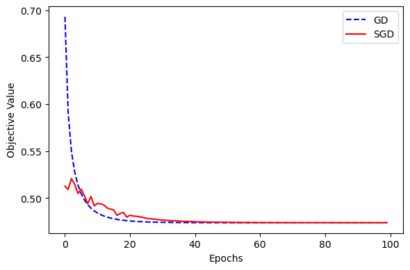

```python
import matplotlib.pyplot as plt
%matplotlib inline

fig = plt.figure(figsize=(6, 4))

epochs_gd = range(len(objvals_gd))
epochs_sgd = range(len(objvals_sgd))

line0, = plt.plot(epochs_gd, objvals_gd, '--b') #, LineWidth=4)
line1, = plt.plot(epochs_sgd, objvals_sgd, '-r') #, LineWidth=2)
plt.xlabel('Epochs')
plt.ylabel('Objective Value')

plt.legend([line0, line1], ['GD', 'SGD'])
plt.tight_layout()
plt.show()
fig.savefig('compare_gd_sgd.pdf', format='pdf', dpi=1200)
```

# 5. Prediction

```python
# Predict class label
# Inputs:
#     w: d-by-1 matrix
#     X: m-by-d matrix
# Return:
#     f: m-by-1 matrix, the predictions
def predict(w, X):
    xw = np.dot(X, w)
    f = np.sign(xw)
    return f
```

```python
# evaluate training error
f_train = predict(w, x_train)
diff = np.abs(f_train - y_train) / 2
error_train = np.mean(diff)
print('Training classification error is ' + str(error_train))
```

```
Training classification error is 0.23125
```

```python
# evaluate test error
f_test = predict(w, x_test)
diff = np.abs(f_test - y_test) / 2
error_test = np.mean(diff)
print('Test classification error is ' + str(error_test))
```

```
Test classification error is 0.2109375
```

# 6. Mini-batch SGD (fill the code)

## 6.1. Compute the objective $Q_I$ and its gradient using a batch of samples

Define $Q_I (w) = \frac{1}{b} \sum_{i \in I} \log \Big( 1 + \exp \big( - y_i x_i^T w \big) \Big) + \frac{\lambda}{2} \| w \|_2^2 $, where $I$ is a set containing $b$ indices randomly drawn from $\{ 1, \cdots , n \}$ without replacement.

The stochastic gradient at $w$ is $g_I = \frac{\partial Q_I }{ \partial w} = \frac{1}{b} \sum_{i \in I} \frac{- y_i x_i }{1 + \exp ( y_i x_i^T w)} + \lambda w$.

```python
# Calculate the objective Q_I and the gradient of Q_I
# Inputs:
#     w: d-by-1 matrix
#     xi: b-by-d matrix
#     yi: b-by-1 matrix
#     lam: scalar, the regularization parameter
#     b: integer, the batch size
# Return:
#     obj: scalar, the objective Q_i
#     g: d-by-1 matrix, gradient of Q_i
def mb_stochastic_objective_gradient(w, xi, yi, lam, b):
    # Fill the function
    # Follow the implementation of stochastic_objective_gradient
    # Use matrix-vector multiplication; do not use FOR LOOP of vector-vector multiplications

    loss_term = np.mean(np.log(1 + np.exp(np.multiply(-yi, np.dot(xi, w)))))
    regularization_term = (lam / 2) * np.sum(w**2)
    obj = loss_term + regularization_term
    gradient_loss_term = (-1/b) * np.dot(xi.T, yi / (1 + np.exp(np.multiply(yi, np.dot(xi, w)))))
    g = gradient_loss_term + lam * w

    return obj, g
```

## 6.2. Implement mini-batch SGD

Hints:

1. In every epoch, randomly permute the $n$ samples (just like SGD).
2. Each epoch has $\frac{n}{b}$ iterations. In every iteration, use $b$ samples, and compute the gradient and objective using the `mb_stochastic_objective_gradient` function. In the next iteration, use the next $b$ samples, and so on.

```python
# Mini-Batch SGD for solving logistic regression
# Inputs:
#     x: n-by-d matrix
#     y: n-by-1 matrix
#     lam: scalar, the regularization parameter
#     b: integer, the batch size
#     stepsize: scalar
#     max_epoch: integer, the maximal epochs
#     w: d-by-1 matrix, initialization of w
# Return:
#     w: the solution
#     objvals: record of each iteration's objective value
def mb_sgd(x, y, lam, b, stepsize, max_epoch=100, w=None):
    # Fill the function
    # Follow the implementation of sgd
    # Record one objective value per epoch (not per iteration!)

    n, d = x.shape
    objvals = np.zeros(max_epoch) # store the objective values

    if w is None:
        w = np.zeros((d, 1)) # zero initialization


    for t in range(max_epoch):
        # randomly shuffle the samples
        rand_indices = np.random.permutation(n)
        x_rand = x[rand_indices]
        y_rand = y[rand_indices].reshape(-1, 1)

        num_batches = n // b
        objval = 0 # accumulate the objective values

        for i in range(num_batches):
            start_idx = i * b
            end_idx = start_idx + b

            xi = x_rand[start_idx: end_idx] # 1-by-d matrix
            yi = y_rand[start_idx: end_idx] # scalar

            obj, g = mb_stochastic_objective_gradient(w, xi, yi, lam, b)

            w -= stepsize * g
            objval += obj

        objval /= num_batches
        objvals[t] = objval

        #objvals.append(objval)

        print('Objective value at epoch t=' + str(t) + ' is ' + str(objval))

    return w, objvals
```

## 6.3. Run MB-SGD

```python
# MB-SGD with batch size b=8
lam = 1E-6 # do not change
b = 8 # do not change
stepsize = .004  # you must tune this parameter

w, objvals_mbsgd8 = mb_sgd(x_train, y_train, lam, b, stepsize)
```

```
Objective value at epoch t=0 is 0.6748626510500134
Objective value at epoch t=1 is 0.6427942007745677
Objective value at epoch t=2 is 0.6179597640956117
Objective value at epoch t=3 is 0.598394233256841
Objective value at epoch t=4 is 0.5826269167104834
Objective value at epoch t=5 is 0.5697494412695672
Objective value at epoch t=6 is 0.5590054051798197
Objective value at epoch t=7 is 0.5500047030691684
Objective value at epoch t=8 is 0.5423681027444122
Objective value at epoch t=9 is 0.5358134416661111
Objective value at epoch t=10 is 0.5301287859929424
Objective value at epoch t=11 is 0.5251346466860275
Objective value at epoch t=12 is 0.5207814533483306
Objective value at epoch t=13 is 0.5168819993997912
Objective value at epoch t=14 is 0.5134681857360118
Objective value at epoch t=15 is 0.5103536093415292
Objective value at epoch t=16 is 0.5075827622865549
Objective value at epoch t=17 is 0.5051334292996341
Objective value at epoch t=18 is 0.5028676062245594
Objective value at epoch t=19 is 0.5007902593566178
Objective value at epoch t=20 is 0.4989364040422714
Objective value at epoch t=21 is 0.4972729448369645
Objective value at epoch t=22 is 0.4956936281826456
Objective value at epoch t=23 is 0.49423188927301914
Objective value at epoch t=24 is 0.4929631507364521
Objective value at epoch t=25 is 0.491753823179483
Objective value at epoch t=26 is 0.4906709363957975
Objective value at epoch t=27 is 0.4895969766095794
Objective value at epoch t=28 is 0.48870079347500867
Objective value at epoch t=29 is 0.48778456405290777
Objective value at epoch t=30 is 0.4869742753289463
Objective value at epoch t=31 is 0.48618967510488964
Objective value at epoch t=32 is 0.4855174232469608
Objective value at epoch t=33 is 0.4848253758828375
Objective value at epoch t=34 is 0.4842581992789959
Objective value at epoch t=35 is 0.4836529959820456
Objective value at epoch t=36 is 0.48309561445466154
Objective value at epoch t=37 is 0.4826133818591772
Objective value at epoch t=38 is 0.48214962371835773
Objective value at epoch t=39 is 0.48173162620338916
```

[output cut: 45 more lines]

```
Objective value at epoch t=85 is 0.47498813546342633
Objective value at epoch t=86 is 0.4749578479945435
Objective value at epoch t=87 is 0.4748834701096625
Objective value at epoch t=88 is 0.4748749547422849
Objective value at epoch t=89 is 0.4748603375545228
Objective value at epoch t=90 is 0.47478460364010144
Objective value at epoch t=91 is 0.47479773273142956
Objective value at epoch t=92 is 0.474790051085577
Objective value at epoch t=93 is 0.474759054858079
Objective value at epoch t=94 is 0.4746908042087597
Objective value at epoch t=95 is 0.47471841605823145
Objective value at epoch t=96 is 0.47465188452700124
Objective value at epoch t=97 is 0.47462933563482607
Objective value at epoch t=98 is 0.4746262099971769
Objective value at epoch t=99 is 0.47460255602519075
```

```python
# MB-SGD with batch size b=64
lam = 1E-6 # do not change
b = 64 # do not change
stepsize = 0.04 # you must tune this parameter

w, objvals_mbsgd64 = mb_sgd(x_train, y_train, lam, b, stepsize)
```

```
Objective value at epoch t=0 is 0.6723463848528126
Objective value at epoch t=1 is 0.6344541020786918
Objective value at epoch t=2 is 0.6060643943418148
Objective value at epoch t=3 is 0.5848649631130378
Objective value at epoch t=4 is 0.5685543581345237
Objective value at epoch t=5 is 0.5555255710747626
Objective value at epoch t=6 is 0.545245862045594
Objective value at epoch t=7 is 0.536715350510914
Objective value at epoch t=8 is 0.5296660730190108
Objective value at epoch t=9 is 0.5235459200037587
Objective value at epoch t=10 is 0.5185270686990541
Objective value at epoch t=11 is 0.5140617491047038
Objective value at epoch t=12 is 0.5101678687568401
Objective value at epoch t=13 is 0.506656263807004
Objective value at epoch t=14 is 0.5037003815417479
Objective value at epoch t=15 is 0.5009950096697624
Objective value at epoch t=16 is 0.4989088233801344
Objective value at epoch t=17 is 0.49654905286968704
Objective value at epoch t=18 is 0.4949646752350925
Objective value at epoch t=19 is 0.4930893334651829
Objective value at epoch t=20 is 0.4916338176723755
Objective value at epoch t=21 is 0.4903367434959661
Objective value at epoch t=22 is 0.4891378239930243
Objective value at epoch t=23 is 0.4880036155646518
Objective value at epoch t=24 is 0.48679662629354914
Objective value at epoch t=25 is 0.4860421389611866
Objective value at epoch t=26 is 0.48512401273002936
Objective value at epoch t=27 is 0.4844457747291269
Objective value at epoch t=28 is 0.4835789171212482
Objective value at epoch t=29 is 0.48296746350110065
Objective value at epoch t=30 is 0.48246644807307737
Objective value at epoch t=31 is 0.48173715847123616
Objective value at epoch t=32 is 0.48132698600331636
Objective value at epoch t=33 is 0.4809411173481152
Objective value at epoch t=34 is 0.4805062210865197
Objective value at epoch t=35 is 0.4801372973716457
Objective value at epoch t=36 is 0.47963023457348386
Objective value at epoch t=37 is 0.4792179115702278
Objective value at epoch t=38 is 0.4789058526215653
Objective value at epoch t=39 is 0.47870749510446603
```

[output cut: 45 more lines]

```
Objective value at epoch t=85 is 0.4745204370376309
Objective value at epoch t=86 is 0.4744707428806077
Objective value at epoch t=87 is 0.47446192413081667
Objective value at epoch t=88 is 0.47466923423721763
Objective value at epoch t=89 is 0.4745572953222914
Objective value at epoch t=90 is 0.4746029188322233
Objective value at epoch t=91 is 0.4744169165471976
Objective value at epoch t=92 is 0.4744412388449053
Objective value at epoch t=93 is 0.4744189906136055
Objective value at epoch t=94 is 0.4744767688352237
Objective value at epoch t=95 is 0.474429569572154
Objective value at epoch t=96 is 0.47440939164072926
Objective value at epoch t=97 is 0.47444759862760577
Objective value at epoch t=98 is 0.4744420324138878
Objective value at epoch t=99 is 0.4743853126911185
```

# 7. Plot and compare GD, SGD, and MB-SGD

You are required to compare the following algorithms:

- Gradient descent (GD)
- SGD
- MB-SGD with b=8
- MB-SGD with b=64

Follow the code in Section 4 to plot `objective function value` against `epochs`. There should be four curves in the plot; each curve corresponds to one algorithm.

Hint: Logistic regression with $\ell_2$-norm regularization is a strongly convex optimization problem. All the algorithms will converge to the same solution. **In the end, the `objective function value` of the 4 algorithms will be the same. If not the same, your implementation must be wrong. Do NOT submit wrong code and wrong result!**

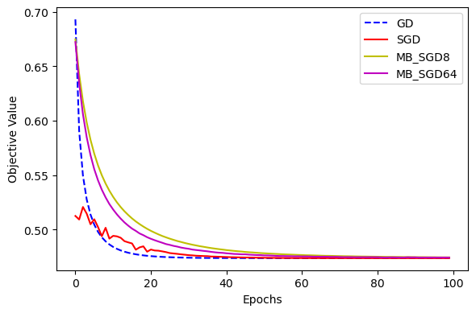

```python
# plot the 4 curves:

import matplotlib.pyplot as plt
%matplotlib inline

fig = plt.figure(figsize=(6, 4))

epochs_gd = range(len(objvals_gd))
epochs_sgd = range(len(objvals_sgd))
epochs_mb8_sgd = range(len(objvals_mbsgd8))
epochs_mb64_sgd = range(len(objvals_mbsgd64))

line0, = plt.plot(epochs_gd, objvals_gd, '--b') #, LineWidth=4)
line1, = plt.plot(epochs_sgd, objvals_sgd, '-r') #, LineWidth=2)
line2, = plt.plot(epochs_mb8_sgd, objvals_mbsgd8, '-y') #, LineWidth=2)
line3, = plt.plot(epochs_mb64_sgd, objvals_mbsgd64, '-m') #, LineWidth=2)

plt.xlabel('Epochs')
plt.ylabel('Objective Value')

#plt.legend([line0, line1, line3], ['GD', 'SGD', 'MB_SGD64'])
plt.legend([line0, line1, line2, line3], ['GD', 'SGD', 'MB_SGD8', 'MB_SGD64'])
plt.tight_layout()
plt.show()
fig.savefig('compare_gd_sgd.pdf', format='pdf', dpi=1200)
```